# ASI assessed exercise 2017/2018

**STUDENT:** Soufiane MOUTEI

Let's start with importing some python libraries:

```python
import numpy as np
import matplotlib.pyplot as plt
import pandas as pd
import seaborn as sns # Seaborn visualization library
from time import time
%matplotlib inline
sns.set(style='ticks')

from sklearn.metrics import accuracy_score, log_loss, confusion_matrix, mean_squared_error

import warnings
warnings.filterwarnings('ignore')
```

Question 1:  
Download the Fashion MNIST and CIFAR10 datasets and import them.

Let's import the Fashion MNIST data:

```python
mnist_train = pd.read_csv('fashion-mnist_train.csv')
mnist_train_X = mnist_train.drop('label', axis=1).as_matrix()
mnist_train_label = mnist_train.label.as_matrix()

mnist_test = pd.read_csv('fashion-mnist_test.csv')
mnist_test_X = mnist_test.drop('label', axis=1).as_matrix()
mnist_test_label = mnist_test.label.as_matrix()

mnist_labels = ["T-shirt/top", "Trouser", "Pullover", "Dress", "Coat", "Sandal", "Shirt", "Sneaker", "Bag", "Ankle boot"]
```

Let's import the CIFAR10 data (we can use also *keras.cifar10*):

```python
def unpickle(file):
    import pickle
    with open(file, 'rb') as fo:
        dict = pickle.load(fo, encoding='bytes')
    return dict
```

```python
data_batch_1 = unpickle('data_batch_1')
data_batch_2 = unpickle('data_batch_2')
data_batch_3 = unpickle('data_batch_3')
data_batch_4 = unpickle('data_batch_4')
data_batch_5 = unpickle('data_batch_5')
test_batch = unpickle('test_batch')

cifar_train_X = np.concatenate((
    data_batch_1[b'data'], data_batch_2[b'data'], data_batch_3[b'data'], data_batch_4[b'data'], data_batch_5[b'data']
))
cifar_train_label = np.array(data_batch_1[b'labels'] + data_batch_2[b'labels'] + data_batch_3[b'labels'] + data_batch_4[b'labels'] + data_batch_5[b'labels'])

cifar_test_X = test_batch[b'data']
cifar_test_label = np.array(test_batch[b'labels'])

cifar_labels = [ 'Airplane', 'Automobile', 'Bird', 'Cat', 'Deer', 'Dog', 'Frog', 'Horse', 'Ship', 'Truck']
```

Question 2:  
Comment on the distribution of class labels and the dimensionality of the input and how these may affect the analysis.

Let's see the distribution of the MNIST data:

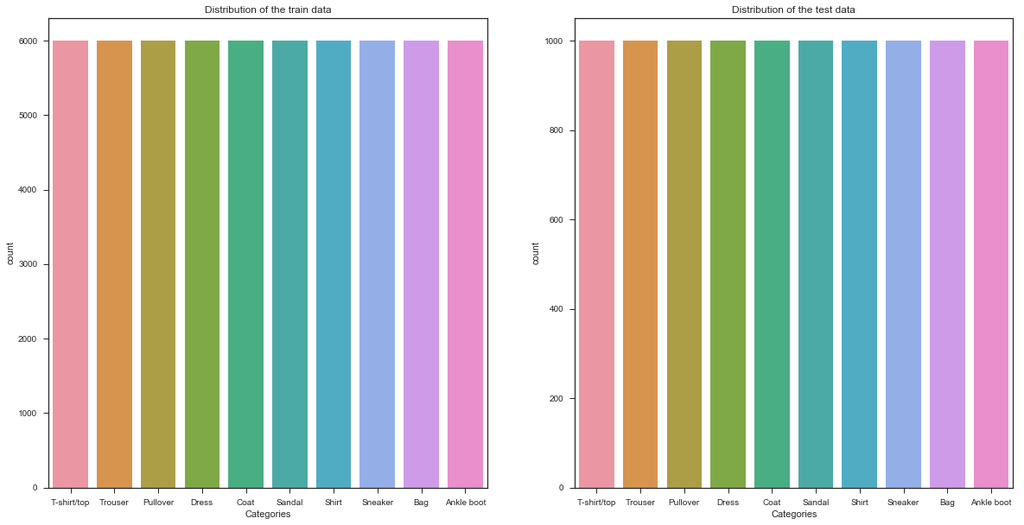

```python
f, (ax1, ax2) = plt.subplots(1, 2, sharex=True, figsize=(20,10))
sns.countplot(mnist_train_label, ax=ax1)
sns.countplot(mnist_test_label, ax=ax2)
ax1.set_title('Distribution of the train data')
ax2.set_title('Distribution of the test data')
ax1.set_xlabel('Categories')
ax2.set_xlabel('Categories')
ax1.set_xticklabels(mnist_labels)
ax2.set_xticklabels(mnist_labels);
```

Let's see now the dimensionality of the MNIST data:

```python
print('Number of training samples for MNIST: %d' % len(mnist_train_label))
print('Number of testing samples for MNIST: %d' % len(mnist_test_label))
print('The shape of MNIST data is: %s' % str(mnist_train_X.shape))
```

```
Number of training samples for MNIST: 60000
Number of testing samples for MNIST: 10000
The shape of MNIST data is: (60000, 784)
```

Let's see the distribution of the CIFAR10 data:

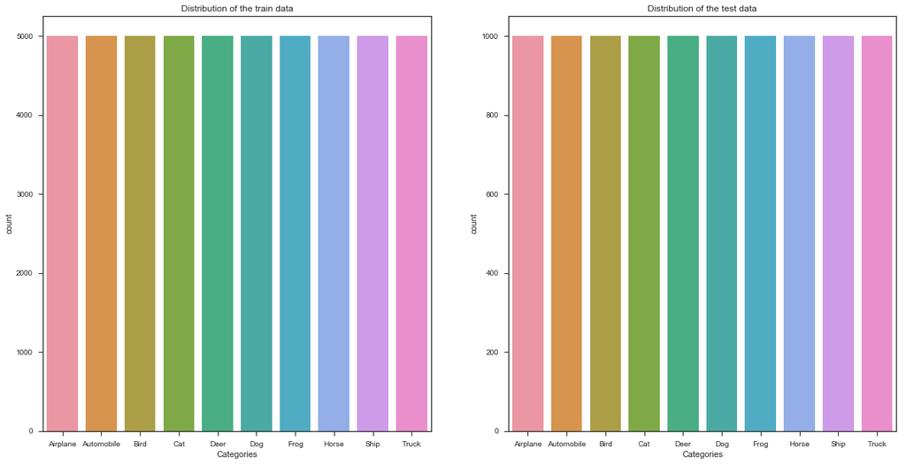

```python
f, (ax1, ax2) = plt.subplots(1, 2, sharex=True, figsize=(20,10))
sns.countplot(cifar_train_label, ax=ax1)
sns.countplot(cifar_test_label, ax=ax2)
ax1.set_title('Distribution of the train data')
ax2.set_title('Distribution of the test data')
ax1.set_xlabel('Categories')
ax2.set_xlabel('Categories')
ax1.set_xticklabels(cifar_labels)
ax2.set_xticklabels(cifar_labels);
```

Let's see now the dimensionality of the CIFAR10 data:

```python
print('Number of training samples for CIFAR10: %d' % len(cifar_train_label))
print('Number of testing samples for CIFAR10: %d' % len(cifar_test_label))
print('The shape of CIFAR10 is: %s' % str(cifar_train_X.shape))
```

```
Number of training samples for CIFAR10: 50000
Number of testing samples for CIFAR10: 10000
The shape of CIFAR10 is: (50000, 3072)
```

Before commenting on these results, let's see some pictures of our data to see the problem we're working on:

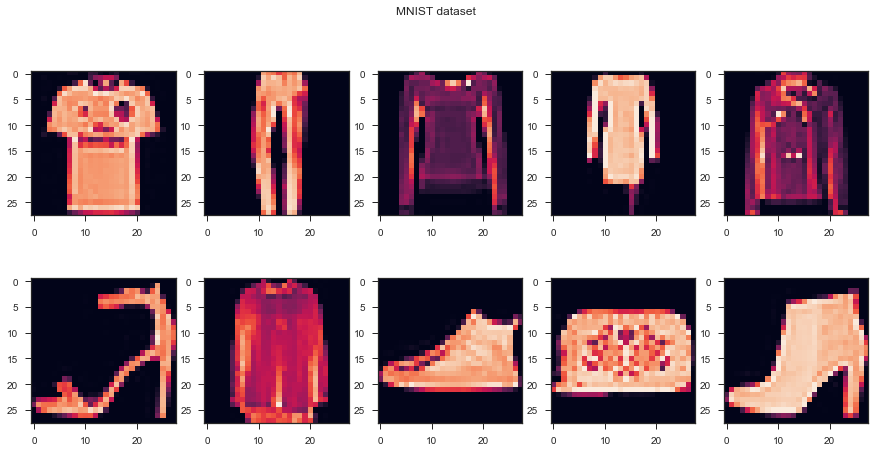

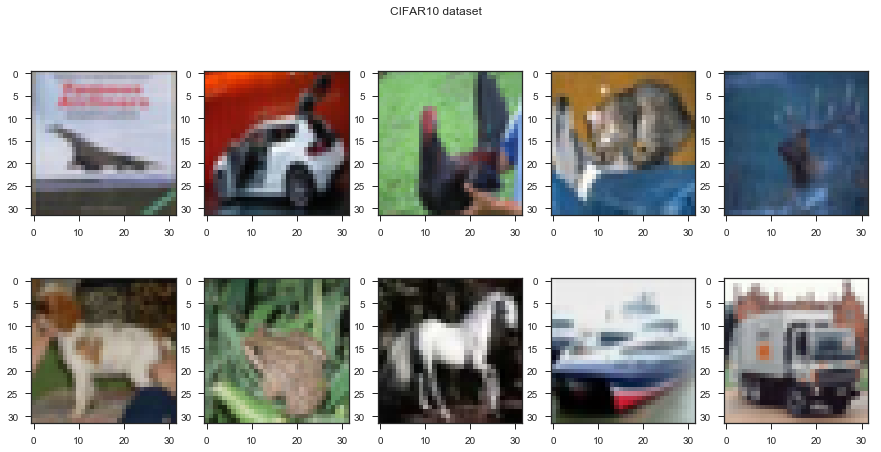

```python
mnist_gray_X_test = mnist_test_X.reshape(mnist_test_X.shape[0], 28, 28)
cifar_gray_X_test = cifar_test_X.reshape(cifar_test_X.shape[0], 3, 32, 32)

fig, axes = plt.subplots(2, 5, figsize=(15, 7))
for i, ax in enumerate(axes.flatten()):
    img = mnist_gray_X_test[np.where(mnist_test_label==i)[0][0]]
    ax.imshow(img)

plt.suptitle('MNIST dataset')
plt.show()

fig, axes = plt.subplots(2, 5, figsize=(15, 7))
for i, ax in enumerate(axes.flatten()):
    img = cifar_gray_X_test[np.where(cifar_test_label==i)[0][0]].transpose([1, 2, 0])
    ax.imshow(img)

plt.suptitle('CIFAR10 dataset')
plt.show()
```

COMMENT  
We can see that both MNIST and CIFAR10 data labels are uniformly distributed in both train and test data which is good for predictions (also, we can a uniform prior $P(t=k) = \frac{1}{10}$). Concerning dimensionality, MNIST data have a dimensionality of $784$ features while CIFAR10 data are bigger and have a dimensionality of $3072$ features which is a huge difference. The number of CIFAR10 training samples is less than MNIST. So, we expect a remarkable difference in the performances. Anyway, the number of features is big and each feature has a value between $0$ and $255$, the chances of having an overflow/underflow are high.

Question 3: Classification  
Question **a** Implement the Naïve Bayes classifier.

Our probabilistic classifier is based on **Bayes rule**: \begin{equation} P(t_{new}=k | \mathbf{X}, \mathbf{t}, \mathbf{x_{new}}) = \dfrac{P(\mathbf{x_{new}} \ | \ t_{new}=k, \mathbf{X}, \mathbf{t})P(t_{new}=k)} {\sum_{j} P(\mathbf{x_{new}} \ | \ t_{new}=j, \mathbf{X}, \mathbf{t})P(t_{new}=j) } \end{equation} We need to define a **likelihood** and a **prior**.  
- **Likelihood**: we're going to use a **Gaussian Likelihood**: \begin{equation} P(\mathbf{x} \ | \ t=k, \mathbf{X}, \mathbf{t}) = \prod_{d=1}^{number \ of \ features} \mathcal{N}(\mu_{kd}, \sigma_{kd} ^{2}) \end{equation}

where the parameters are: $\mu_{kd}=\dfrac{1}{N_k}\sum_{n:t_n=k}x_{nd}$ and $\sigma_{kd} ^{2}=\dfrac{1}{N_k}\sum_{n:t_n=k}(x_{nd}-\mu_{kd})^2$ ($N_k$ is just the number of raws labeled by $k$).

- **Prior**: we're going to use a **uniform** prior: \begin{equation} P(t_{new}=k) = \frac{1}{K} \end{equation}

where $K$ is the number of classes.

**Fitting** will be a matter of calculating the means and the variances (for the Gaussian Likelihood) and updating the prior.  
**Predicting** will be as follows:

1. Given a sample $\mathbf{x}_{new}$, we compute the **posterior** $P(t_{new}=k \ | \ \mathbf{x_{new}}, \mathbf{X},\mathbf{t})$ for each $k$.
2. Compute the new label using: \begin{equation} t_{new} = \arg\max_{k} P(t_{new}=k \ | \ \mathbf{x_{new}}, \mathbf{X},\mathbf{t}) = \arg\max_{k} P(\mathbf{x_{new}} \ | \ t_{new}=k, \mathbf{X}, \mathbf{t}) \times P(t_{new}=k) \end{equation} The **marginal** is ignored since it's only a normalization factor and does not influence the predictions. For better **numerical stability**, we use **log-likelihood**.

In order not to avoid **zero frequency problem**, which occurs when we have no occurrences of a class label and a certain attribute value together then the frequency-based probability estimate will be zero. To solve this problem, we'll shift the zero frequencies to slightly higher value.

```python
class NaiveBayesClassifier(object):
    def __init__(self, epsilon=1e-2):
        self.K = 0 # The number of classes
        self.means = [] # The list of means
        self.variances = [] # The list of variances
        self.epsilon = epsilon # The bound to consider a zero frequency problem

    def log_likelihood(self, x_new):
        def log_normal(x, mu, var):
            """
            The logarithm of the normal distributions
            """
            return - np.log(np.sqrt(2 * np.pi * var)) - ((x - mu) ** 2) / (2 * var)

        log_likelihoods = np.zeros(self.K, dtype=np.float128) # In this array, the log-likelihoods given each class will be saved

        for i in range(0, self.K):
            log_likelihoods[i] = np.sum(log_normal(x_new, self.means[i], self.variances[i]))
        return log_likelihoods

    def prior(self, t):
        self.prior = np.ones(self.K, dtype=np.float128) / self.K

    def fit(self, X, t):
        t0 = time()

        self.K = len(np.unique(t)) # The number of classes is the number of unique elements in the labels list of X

        for k in range(0, self.K):
            X_k = X[np.where(t == k)] # We extract rows belonging to class k

            # We add the mean (shape=number of features) to the list.
            # We use np.atleast_1d in case of X_k is a vector, so the mean won't be a number.
            self.means.append(np.atleast_1d(np.mean(X_k, axis=0, dtype=np.float128)))

            var = np.atleast_1d(np.var(X_k, axis=0, dtype=np.float128)) # The variance vector. We use np.atleast_1d in case of X_k is a vector

            for i in range(len(var)):
                if var[i] < self.epsilon:
                    var[i] += self.epsilon # Shift zero frequencies by epsilon

            self.variances.append(var) # We add the variance (shape=number of features) to the list

        self.prior(t) # We update the prior

        print('\t-- Training completed in %.2f seconds --' % (time() - t0))

    def predict(self, X):
        t0 = time()

        t = np.zeros(len(X), dtype=int) # The future predicted labels list

        for i, x in enumerate(X):
            log_likelihoods = self.log_likelihood(x)

            posterior = np.log(self.prior, dtype=np.float128) + log_likelihoods

            t[i] = np.argmax(posterior)

        print('\t-- Classification completed in %.2f seconds --' % (time() - t0))

        return t

    def predict_proba(self, X):
        t0 = time()

        t = []

        for x in X:
            log_likelihoods = self.log_likelihood(x)
            t.append(np.exp(log_likelihoods, dtype=np.float128)) # We use only the log-likehood

        print('\t-- Probability prediction completed in %.2f seconds --' % (time() - t0))

        return np.array(t, dtype=np.float128)
```

Question **b** Describe a positive and a negative feature of the classifier for these tasks.

ANSWER

- **Positive features of the classifier**: It's a simple classifier. We don't have any interactions between two features $x_i$ and $x_j$ with $i≠j$. Thanks to that, we reduce many calculations on the likelihood. In fact, without the independence assumption, we would have a covariance matrix $\underset{784 \times 784}{\Sigma}$ (for example, for MNIST data, worse for CIFAR10), and with the Naïve Bayes classifier we'll have to work out only $784$ (again, for MNIST data) instead for the variances. In addition, besides the size of the matrix that would be ($784 \times 784$), we would have to invert $\Sigma$ to calculate the likelihood. So, Naïve Bayes classifier gives us a quick convergence.
- **Negative features of the classifier**: The assumption that the input features are independent is in general not correct (correlations are important). The classifier performances depend on the quality of our data and an unbalanced distribution of the labels may produce biased predictions.

Question **c** Describe any data pre-processing that you suggest for this data and your classifier.

ANSWER  
The interval of variations of features $[0,255]$ given the huge number of features may lead to overflow while computing intermediate results. So we're going to normalize the features values.

Question **d** Apply your classifier to the two given datasets. Make sure your optimization is clearly commented. Use classification accuracy and test log-likelihood as your figures of merit.

```python
# Normalize features
cifar_train_X_normalized = cifar_train_X / 255
cifar_test_X_normalized = cifar_test_X / 255
mnist_train_X_normalized = mnist_train_X / 255
mnist_test_X_normalized = mnist_test_X / 255
```

```python
print("---- MNIST data prediction ----")
mnist_classifier = NaiveBayesClassifier() # Initiliazing the naive bayes classifier class
mnist_classifier.fit(mnist_train_X_normalized, mnist_train_label) # Fitting the train data

mnist_predictions =  mnist_classifier.predict(mnist_test_X_normalized) # Predicting the test data labels
mnist_predicted_proba =  mnist_classifier.predict_proba(mnist_test_X_normalized) # Predicting the test data likelihoods

print("\t\tClassification accuracy: %.2f %%" % (accuracy_score(mnist_test_label, mnist_predictions) * 100))
print("\t\tClassification log-likelihood loss: %.2f" % (log_loss(mnist_test_label, mnist_predicted_proba)))
```

```
---- MNIST data prediction ----
	-- Training completed in 1.78 seconds --
	-- Classification completed in 6.40 seconds --
	-- Probability prediction completed in 6.24 seconds --
		Classification accuracy: 69.83 %
		Classification log-likelihood loss: 2.77
```

```python
print("---- CIFAR10 data prediction ----")
cifar_classifier = NaiveBayesClassifier(epsilon=0) # Initiliazing the naive bayes classifier class
cifar_classifier.fit(cifar_train_X_normalized, cifar_train_label) # Fitting the train data

cifar_predictions =  cifar_classifier.predict(cifar_test_X_normalized) # Predicting the test data labels
cifar_predicted_proba =  cifar_classifier.predict_proba(cifar_test_X_normalized) # Predicting the test data likelihoods

print("\t\tClassification accuracy: %.2f %%" % (accuracy_score(cifar_test_label, cifar_predictions) * 100))
print("\t\tClassification log-likelihood loss: %.2f" % (log_loss(cifar_test_label, cifar_predicted_proba)))
```

```
---- CIFAR10 data prediction ----
	-- Training completed in 6.35 seconds --
	-- Classification completed in 18.40 seconds --
	-- Probability prediction completed in 20.01 seconds --
		Classification accuracy: 29.76 %
		Classification log-likelihood loss: 5.82
```

Question **e** Display the confusion matrix on the test data.

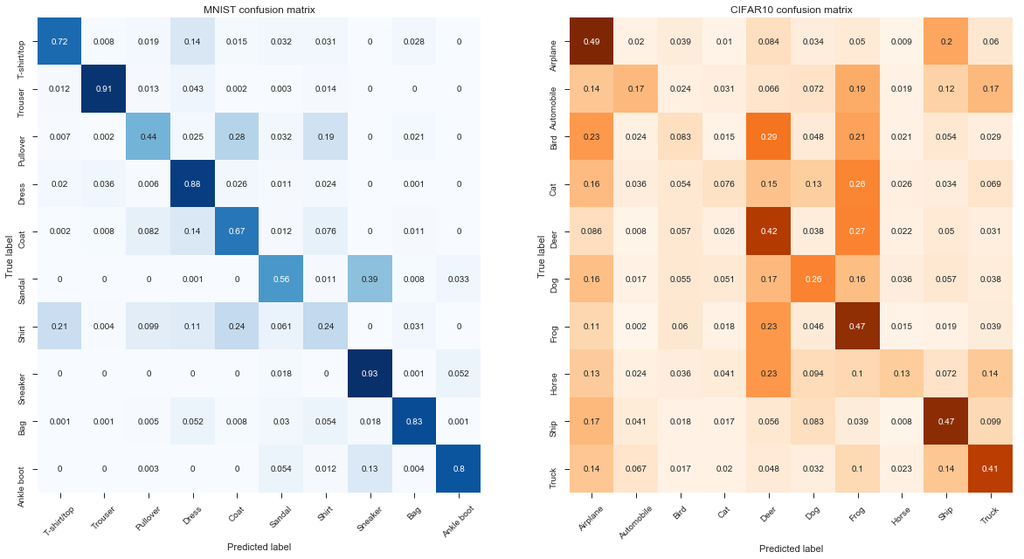

```python
# The MNIST confusion matrix
mnist_conf = confusion_matrix(y_true=mnist_test_label, y_pred=mnist_predictions)
mnist_conf_norm = mnist_conf / mnist_conf.sum(axis=1) # Normalisation

# The CIFAR10 confusion matrix
cifar_conf = confusion_matrix(y_true=cifar_test_label, y_pred=cifar_predictions)
cifar_conf_norm = cifar_conf / cifar_conf.sum(axis=1) # Normalisation

f, (ax1, ax2) = plt.subplots(1, 2, figsize=(20,10))

sns.heatmap(mnist_conf_norm, cbar=False, cmap=plt.cm.Blues, annot=True, ax=ax1)
ax1.set_title("MNIST confusion matrix")
ax1.set_xlabel("Predicted label")
ax1.set_ylabel("True label")
ax1.set_xticklabels(mnist_labels, rotation=45)
ax1.set_yticklabels(mnist_labels)


sns.heatmap(cifar_conf_norm, cbar=False, cmap=plt.cm.Oranges, annot=True, yticklabels=np.arange(10), ax=ax2)
ax2.set_title("CIFAR10 confusion matrix")
ax2.set_xlabel("Predicted label")
ax2.set_ylabel("True label")
ax2.set_xticklabels(cifar_labels, rotation=45)
ax2.set_yticklabels(cifar_labels)
plt.show()
```

Question **f** Discuss the performance, compare them against a classifier that outputs random class labels, and suggest ways in which performance could be improved.

Let's implement a classifier that outputs random class labels:

```python
mnist_pred_random = np.random.randint(0, 10, len(mnist_test_label))
cifar_pred_random = np.random.randint(0, 10, len(cifar_test_label))

print("Accuracy for random classifier with MNIST: %.2f %%" % (accuracy_score(mnist_test_label, mnist_pred_random) * 100))
print("Accuracy for random classifier with CIFAR10: %.2f %%" % (accuracy_score(cifar_test_label, cifar_pred_random) * 100))
```

```
Accuracy for random classifier with MNIST: 10.27 %
Accuracy for random classifier with CIFAR10: 10.19 %
```

ANSWER

- We can see that our classifier performs a lot better on the MNIST data ($\simeq 70 \% $ accuracy) than on the CIFAR10 data ($\simeq 30 \% $ accuracy).
- Given the confusion matrix, we can see that *T-shirt/top*, *Trouser*, *Dress*, *Sneaker*, *Bag* and *Ankle boot* on MNIST data are very well-classified while *Shirt* are not and confused sometimes with *Coat* and other times with *T-shirt/top*. *Pullover*, *Coat* and *Sandal* are half of the times well-classified. *Sandal* are $39 \%$ of the times confused with *Sneaker*. For the CIFAR10 data, the results are very bad. Only few classes that are well-classified almost $50 \%$ of the times, but it's still bad. The other classes are most of the times misclassified. So, the confusion matrix confirms the accuracy results that our classifier works a lot better on the MNIST data.
- The random classifier has an accuracy of $\frac{1}{K}$. Our Naive Bayes Classifier performs indeed bad on the CIFAR10 dataset but it's still better than a random classifier.

We can improve theses results by taking into account correlation between features (which means the features should not be indepedent). We can use for example a likelihood with a **Multivariate Gaussian** distribution.

Question 4: Linear regression  
Question **a** Implement Bayesian linear regression.

Our probabilistic regressor is based on **Bayes rule**: \begin{equation} P(\mathbf{w} | \mathbf{X}, \mathbf{t}) = \dfrac{P(\mathbf{t} | \mathbf{X}, \mathbf{w})P(\mathbf{w})} {P(\mathbf{t} | \mathbf{X}) } \end{equation} We need to define a **likelihood** and a **prior**.  
- **Likelihood**: we're going to use a **Gaussian Likelihood**: \begin{equation} P(\mathbf{t} | \mathbf{X}, \mathbf{w}, \sigma^{2}) = \mathcal{N}(\mathbf{X}\mathbf{w}, \sigma^{2}\mathbf{I}) \end{equation}

where the parameters are: $\mathbf{w} = (\mathbf{X}^T\mathbf{X})^{-1}\mathbf{X}^T\mathbf{t}$ and $\sigma^{2} = \frac{(\mathbf{t} - \mathbf{X}\mathbf{w})^T (\mathbf{t} - \mathbf{X}\mathbf{w})}{len(\mathbf{t})}$.

- **Prior** (the choice of the prior won't have a great impact on our predictions since our data are big): the prior conjugate to the Gaussian is Gaussian. So we're choosing: \begin{equation} P(w) = \mathcal{N}(0, \mathbf{S}) \end{equation}

where $\mathbf{S} = \mathbf{I}$.

Giving the course, this will give us a **posterior**: \begin{equation} P(\mathbf{w} | \mathbf{X}, \mathbf{t}) = \mathcal{N}(\mathbf{\mu}, \mathbf{\Sigma}) \end{equation}

where $\mathbf{\Sigma} = (\frac{1}{\sigma^{2}}\mathbf{X}^T\mathbf{X} + \mathbf{S}^{-1})^{-1}$ and $\mathbf{\mu} = \frac{1}{\sigma^{2}} \mathbf{\Sigma} \ \mathbf{X}^T \mathbf{t}$.

**Fitting** will be a matter of calculating the Gaussian parameters for the **posterior**.  
**Predicting** will be a matter of working out: \begin{equation} \mathbf{t}_{new} = \mathbf{X}_{new} \mathbf{\mu} \end{equation}

We're going to add the slope column (a column of $1$) to $\mathbf{X}$ (and also to $\mathbf{X}_{new}$).

For better predictions, we're going to add polynomials of the features; this means that given a parameter $k \geq 2$, we'll add the powers from $2$ to $k$ of each feature to $\mathbf{X}$ (and also to $\mathbf{X}_{new}$).

```python
class BayesianLinearRegression(object):
    def __init__(self, order=2):
        self.order = order # The polynomial order to use
        self.w_hat = None # The weights for the least squares solution in vector form
        self.sigma2_hat = None # The variance of the likelihood
        self.post_cov = None # The posterior covariance
        self.post_mu = None # The posterior mean

    def _X(self, X):
        columns = [np.ones((len(X), 1)), X] # Add the slope and X

        for i in range(2, self.order + 1):
            columns.append(np.power(X, i))

        _X = np.hstack(tuple(columns))
        return _X

    def fit(self, X, t, seed=None):
        t0 = time()

        _X = self._X(X)
        XTX = np.dot(_X.T, _X)

        self.w_hat = np.linalg.inv(XTX).dot(_X.T).dot(t) # The weights for the least squares solution in vector form

        # The likelihood parameters (the likelihood mean is _X.dot(w_hat)): Gaussian(_X.dot(w_hat), sigma2_hat)
        diff = t - np.dot(_X, self.w_hat)
        self.sigma2_hat = np.dot(diff.T, diff) / len(t) # The variance of the likelihood

        # The prior: Gaussian N(0,S)
        # The choice of the prior won't have a great impact on our predictions since our data are big
        S = np.eye(_X.shape[1])

        # The posterior: Gaussian(post_mu, post_cov)
        self.post_cov = np.linalg.inv(XTX / self.sigma2_hat + np.linalg.inv(S))
        self.post_mu = (self.post_cov.dot(_X.T).dot(t)) / self.sigma2_hat

        print('\t-- Training completed in %.2f seconds --' % (time() - t0))

    def predict(self, X):
        t0 = time()

        _X = self._X(X)

        t = _X.dot(self.post_mu)

        print('\t-- Classification completed in %.2f seconds --' % (time() - t0))

        return t
```

Question **b** Treat class labels as continuous and apply regression to the training data.

```python
print("---- MNIST data prediction ----")
mnist_regressor = BayesianLinearRegression(order=5) # Initiliazing the naive bayes classifier class
mnist_regressor.fit(mnist_train_X_normalized, mnist_train_label) # Fitting the train data

mnist_predictions_regr =  mnist_regressor.predict(mnist_test_X_normalized) # Predicting the test data labels
```

```
---- MNIST data prediction ----
	-- Training completed in 107.86 seconds --
	-- Classification completed in 1.23 seconds --
```

```python
print("---- CIFAR10 data prediction ----")
cifar_regressor = BayesianLinearRegression(order=3) # Initiliazing the naive bayes classifier class
cifar_regressor.fit(cifar_train_X_normalized, cifar_train_label) # Fitting the train data

cifar_predictions_regr =  cifar_regressor.predict(cifar_test_X_normalized) # Predicting the test data labels
```

```
---- CIFAR10 data prediction ----
	-- Training completed in 958.54 seconds --
	-- Classification completed in 3.84 seconds --
```

Question **c** Produce a scatter plot showing the predictions versus the true targets for the test set and compute the mean squared error on the test set

```
---- MNIST data prediction ----
		MSE: 1.69
		RMSE: 1.30
---- CIFAR10 data prediction ----
		MSE: 7.64
		RMSE: 2.76
```

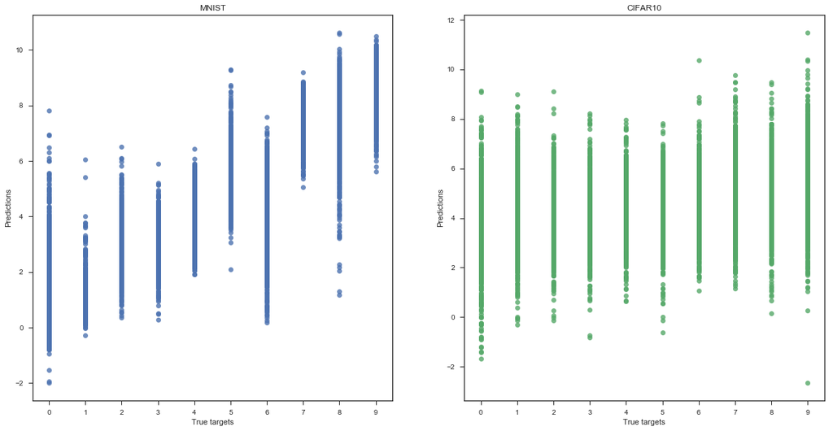

```python
print("---- MNIST data prediction ----")
print("\t\tMSE: %.2f" % (mean_squared_error(mnist_test_label, mnist_predictions_regr)))
print("\t\tRMSE: %.2f" % (np.sqrt(mean_squared_error(mnist_test_label, mnist_predictions_regr))))

print("---- CIFAR10 data prediction ----")
print("\t\tMSE: %.2f" % (mean_squared_error(cifar_test_label, cifar_predictions_regr)))
print("\t\tRMSE: %.2f" % (np.sqrt(mean_squared_error(cifar_test_label, cifar_predictions_regr))))

f, (ax1, ax2) = plt.subplots(1, 2, figsize=(20,10))
sns.regplot(mnist_test_label, mnist_predictions_regr, ax=ax1, fit_reg=False)
sns.regplot(cifar_test_label.reshape(-1), cifar_predictions_regr.reshape(-1), ax=ax2, fit_reg=False)
ax1.set_title('MNIST')
ax1.set_xlabel('True targets')
ax1.set_ylabel('Predictions')
ax1.set_xticks(range(10))
ax2.set_title('CIFAR10')
ax2.set_xlabel('True targets')
ax2.set_ylabel('Predictions')
ax2.set_xticks(range(10));
```

COMMENT  
Some predicted values are out of the range $\{0,...,9\}$. There are many variables that were not well-predicted (by looking at the plot). That's explain the high mean squared error we got.

Question **d** Suggest a way to discretize predictions and display the confusion matrix on the test data and report accuracy

We can discretize our predictions as follows:

1. Values higher than $9$ are going to be replaced by the $10$th class ($9$ in Python).
2. Values lower than $0$ are going to be replaced by the $1$st class ($0$ in Python).
3. The other values are going to be rounded thanks to the *numpy.round* function.

```
MNIST accuracy: 45.89 %
CIFAR10 accuracy: 12.53 %
```

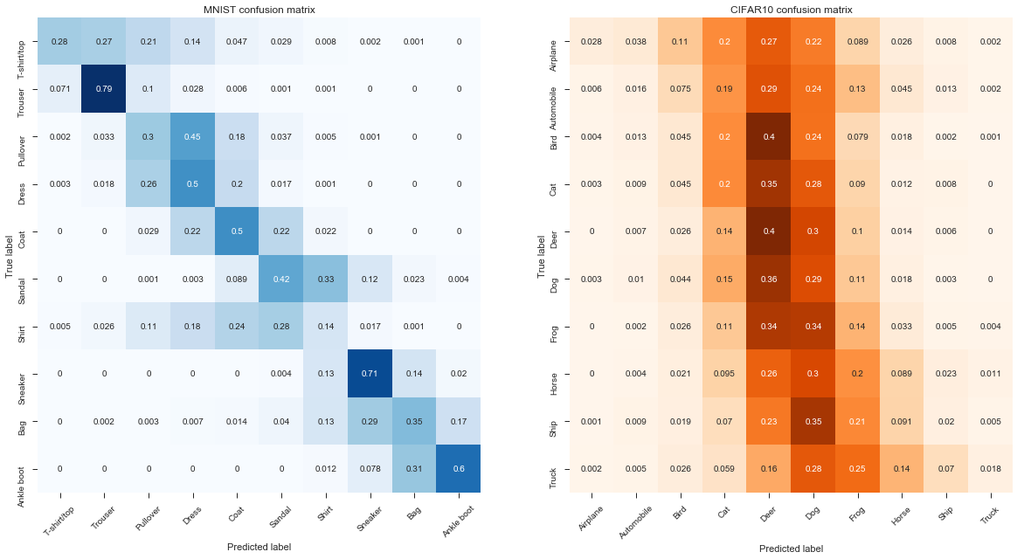

```python
def discretize(t):
    return list(map(lambda u: 9 if u >= 9 else (0 if u <= 0 else int(np.round(u))), t))

mnist_predictions_regr_discretized = discretize(mnist_predictions_regr)
cifar_predictions_regr_discretized = discretize(cifar_predictions_regr)

print("MNIST accuracy: %.2f %%" % (accuracy_score(mnist_test_label, mnist_predictions_regr_discretized) * 100))
print("CIFAR10 accuracy: %.2f %%" % (accuracy_score(cifar_test_label, cifar_predictions_regr_discretized) * 100))

# The MNIST confusion matrix
mnist_conf = confusion_matrix(y_true=mnist_test_label, y_pred=mnist_predictions_regr_discretized)
mnist_conf_norm = mnist_conf / mnist_conf.sum(axis=1) # Normalisation

# The CIFAR10 confusion matrix
cifar_conf = confusion_matrix(y_true=cifar_test_label, y_pred=cifar_predictions_regr_discretized)
cifar_conf_norm = cifar_conf / cifar_conf.sum(axis=1) # Normalisation

f, (ax1, ax2) = plt.subplots(1, 2, figsize=(20,10))

sns.heatmap(mnist_conf_norm, cbar=False, cmap=plt.cm.Blues, annot=True, ax=ax1)
ax1.set_title("MNIST confusion matrix")
ax1.set_xlabel("Predicted label")
ax1.set_ylabel("True label")
ax1.set_xticklabels(mnist_labels, rotation=45)
ax1.set_yticklabels(mnist_labels)


sns.heatmap(cifar_conf_norm, cbar=False, cmap=plt.cm.Oranges, annot=True, yticklabels=np.arange(10), ax=ax2)
ax2.set_title("CIFAR10 confusion matrix")
ax2.set_xlabel("Predicted label")
ax2.set_ylabel("True label")
ax2.set_xticklabels(cifar_labels, rotation=45)
ax2.set_yticklabels(cifar_labels)
plt.show()
```

COMMENT  
Results are worse. Considering labels as continuous and using the Bayesian Linear Regression didn't improve the results. We can see on the confusion matrix that confusions are more likely to happen than before.

Question **e** Discuss regression performance with respect to classification performance

ANSWER  
The regression performances were worse than classification performances. The high dimensionality of the input and the order of the polynomials used to create *_X* matrix affect our results. Increasing the order of polynomials increases accuracy (well, we speak about the first orders) but the complexity as well (which implies more time to fit and then predict). Classification perfomances using Naïve Bayes Classifier were more accurate and faster.

Question **f** Describe one limitation of using regression for this particular task.

ANSWER  
Using regression for this particular task increases the chances of overfitting, the regression model will model the noise in the data and not the relation between the real data. In addition, linear regression models are used in describing linear relationships between variables. If the assumption of a linear relation between the inputs and the output does not hold, the resulting model will be wrong. Moreover, linear regression is sensitive to outliers and that can easily change our regression performances.

Bonus question  
The state-of-the-art in these image classification problems suggests that convolutional layers in convolutional neural networks yield most of the improvements compared to standard neural networks. The reason is that they are capable of modeling spatial patterns through the hierarchical analysis of patches of images. Propose and implement ways to exploit patch information in the Naïve Bayes classifier or linear regression. A couple of suggestions are:

1. Apply Naïve Bayes classification to the output of convolutional layer in the LeNet architecture.
2. Construct the Naïve Bayes classifier by calculating patch-specific statistics and extend this by stacking multiple of these

Let's start with some imports:

```python
import keras
from keras.models import Sequential, Model
from keras.layers.convolutional import Convolution2D, MaxPooling2D
from keras.layers.core import Activation, Flatten, Dense, Dropout
from keras.utils import np_utils
```

We'll use a LeNet architecture based on the hierarchy: Input - (Convolution - ReLU - POOL) - (Convolution - ReLU - POOL) - (Flatten - FC (Fully Connected layer) - ReLU) - (FC - ReLU) - (FC - Softmax):

1. $1^{st}$ **(Convolution - ReLU - POOL)**: The convolution layer will learn $20$ convolution filters, where each filter is of size 5 x 5. The input dimensions of this value are the same width, height and depth as our input images. We'll use the gray scale for our images instead of pixels (for example, for MNIST data, we'll use $28 \times 28$ inputs in each sample instead of $784$). Then, the ReLU activation function will be applied and after we'll use a $2 \times 2$ max-pooling in both the horizontal and vertical direction.
2. $2^{nd}$ **(Convolution - ReLU - POOL)**: The same as before except for the convolution layer, $50$ convolutional filters will be used instead of $20$.
3. **(Flatten - FC - RELU)**: The input here is the output of the *POOL* layer. This output will be flatten into a single vector in order to apply a dense/fully-connected layer. Our fully-connected layer will contain $120$ units that will be the input of the ReLU activation.
4. **(FC - RELU)**: The fully-connected layer will contain $84$ units that will be the input of the ReLU activation.
5. **(FC - Softmax)**: We'll use another fully-connected layer with $10$ units (the number of classes in general). We'll apply finally a softmax classifier.

```python
class LeNet:
    def __init__(self, width, height, depth, K):
        """
        width: The width of our input images.
        height: The height of our input images.
        depth: The number of channels of our input images.
        K: The number of classes in our dataset.
        """

        # Initialize the model to construct the network
        self.model = Sequential()

        # 1st CONV => RELU => POOL
        self.model.add(Convolution2D(20, 5, 5, border_mode="same", input_shape=(height, width, depth)))
        self.model.add(Activation("relu"))
        self.model.add(MaxPooling2D(pool_size=(2, 2), strides=(2, 2)))

        # 2nd of CONV => RELU => POOL
        self.model.add(Convolution2D(50, 5, 5, border_mode="same"))
        self.model.add(Activation("relu"))
        self.model.add(MaxPooling2D(pool_size=(2, 2), strides=(2, 2)))

        # Flatten
        self.model.add(Flatten(name='flatten'))

        self.model.add(Dropout(0.75))

        # 1st FC => RELU
        self.model.add(Dense(120))
        self.model.add(Activation("relu"))

        # 2nd FC => RELU
        self.model.add(Dense(84))
        self.model.add(Activation("relu"))

        # FC => Softmax classifier
        self.model.add(Dense(K))
        self.model.add(Activation("softmax"))

        self.model.compile(
            loss="categorical_crossentropy", optimizer=keras.optimizers.Adam(), metrics=['accuracy']
        )

    def fit(self, X, t, batch_size=128, nb_epoch=5, verbose=0, validation_data=None):
        print('-- Training... --')

        t0 = time()

        self.model.fit(
            X, t, batch_size=batch_size, nb_epoch=nb_epoch, verbose=verbose, validation_data=validation_data
        )
        print('-- Training completed in %.2f seconds --' % (time() - t0))

    def predict(self, X, batch_size=128, verbose=0, steps=None):
        return self.model.predict(X, batch_size=batch_size, verbose=verbose, steps=steps)

    def score(self, X, t, batch_size=128, verbose=0):
        return self.model.evaluate(X, t, batch_size=batch_size, verbose=verbose)
```

Let's prepare our MNIST data and then fit the model.

```python
mnist_train_X_normalized_full = mnist_train_X_normalized.reshape(mnist_train_X_normalized.shape[0], 28, 28, 1)
mnist_test_X_normalized_full = mnist_test_X_normalized.reshape(mnist_test_X_normalized.shape[0], 28, 28, 1)

# Transform the labels into a vector for each label
# where the index of the label is set to 1 and all other entries to 0
# This is necessary for the softmax classifier
mnist_train_label_vectors = np_utils.to_categorical(mnist_train_label, 10)
mnist_test_label_vectors = np_utils.to_categorical(mnist_test_label, 10)

leNet = LeNet(width=28, height=28, depth=1, K=10)
leNet.fit(
    mnist_train_X_normalized_full, mnist_train_label_vectors,
    verbose=1, validation_data=(mnist_test_X_normalized_full, mnist_test_label_vectors)
)

score = leNet.score(mnist_test_X_normalized_full, mnist_test_label_vectors)
print("Classification accuracy: %.2f %%" % (score[1] * 100))
print("Classification loss: %.2f\n" % (score[0]))
```

```
-- Training... --
Train on 60000 samples, validate on 10000 samples
-- Training completed in 396.70 seconds --
Classification accuracy: 90.54 %
Classification loss: 0.26
```

COMMENT  
The training took around $6$ minutes, we can expect a lot more for the CIFAR10 data. The accuracy is $90.54 \%$, the best accuracy we got until now.

Let's build a model to get the output of convolutional layer in the LeNet architecture:

```python
conv_model = Model(
    inputs=leNet.model.input, outputs=leNet.model.get_layer('flatten').output
)

mnist_train_conv = conv_model.predict(mnist_train_X_normalized_full)
mnist_test_conv = conv_model.predict(mnist_test_X_normalized_full)
```

Before applying Naïve Bayes Classifier, let's take a look at the shapes of our input:

```python
print("The shape of our train data:", mnist_train_conv.shape)
print("The shape of our test data:", mnist_test_conv.shape)
```

```
The shape of our train data: (60000, 2450)
The shape of our test data: (10000, 2450)
```

The number of features is a lot bigger than before. However, we don't expect to wait more than $1 \ min$ to train our data with the Naïve Bayes Classifier thanks to its fastness. Let's train our data:

```python
print("---- MNIST data prediction ----")
mnist_classifier2 = NaiveBayesClassifier() # Initiliazing the naive bayes classifier class
mnist_classifier2.fit(mnist_train_conv, mnist_train_label) # Fitting the train data

mnist_predictions2 =  mnist_classifier2.predict(mnist_test_conv) # Predicting the test data labels
mnist_predicted_proba2 =  mnist_classifier2.predict_proba(mnist_test_conv) # Predicting the test data likelihoods

print("\t\tClassification accuracy: %.2f %%" % (accuracy_score(mnist_test_label, mnist_predictions2) * 100))
print("\t\tClassification log-likelihood loss: %.2f\n" % (log_loss(mnist_test_label, mnist_predicted_proba2)))
```

```
---- MNIST data prediction ----
	-- Training completed in 5.89 seconds --
	-- Classification completed in 15.24 seconds --
	-- Probability prediction completed in 15.24 seconds --
		Classification accuracy: 80.08 %
		Classification log-likelihood loss: 2.30
```

COMMENT  
The accuracy is higher now ($80 \%$) comparing to the previous accuracy of the Naïve Bayes Classifier. However, it's still less than the accuracy given by the Neural Network.

Let's take a look at the confusion matrix.

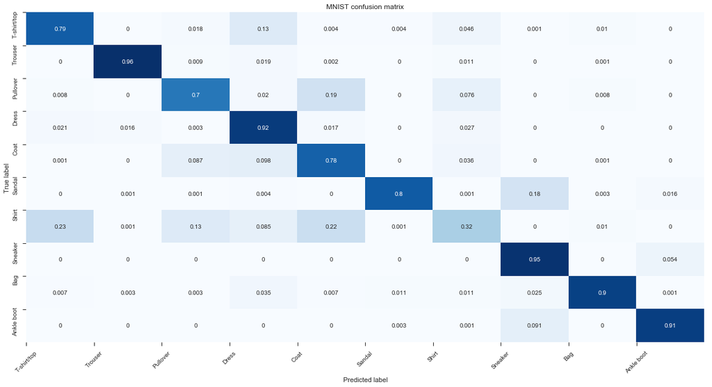

```python
# The MNIST confusion matrix
mnist_conf = confusion_matrix(y_true=mnist_test_label, y_pred=mnist_predictions2)
mnist_conf_norm = mnist_conf / mnist_conf.sum(axis=1) # Normalisation

plt.figure(figsize=(20,10))
sns.heatmap(mnist_conf_norm, cbar=False, cmap=plt.cm.Blues, annot=True)
plt.title("MNIST confusion matrix")
plt.xlabel("Predicted label")
plt.ylabel("True label")
plt.xticks(range(10), mnist_labels, rotation=45)
plt.yticks(range(10), mnist_labels);
```

COMMENT  
Almost all labels were very well-classified although we still always have a problem with the label *Shirt*. We can say that our results improved a lot for several reasons: we used instead of the pixels the gray scales and give them more importance thanks to the convolutional layers - the accuracy got improved thanks to convolutional layers again. The accuracy is still lower than the neural network one's because of the independency assumption.

Let's apply these steps to the CIFAR10 data:

```python
cifar_train_X_normalized_full = cifar_train_X_normalized.reshape(cifar_train_X_normalized.shape[0], 32, 32, 3)
cifar_test_X_normalized_full = cifar_test_X_normalized.reshape(cifar_test_X_normalized.shape[0], 32, 32, 3)

# Transform the labels into a vector for each label
# where the index of the label is set to 1 and all other entries to 0
# This is necessary for the softmax classifier
cifar_train_label_vectors = np_utils.to_categorical(cifar_train_label, 10)
cifar_test_label_vectors = np_utils.to_categorical(cifar_test_label, 10)

leNet = LeNet(width=32, height=32, depth=3, K=10)
leNet.fit(
    cifar_train_X_normalized_full, cifar_train_label_vectors,
    verbose=1, validation_data=(cifar_test_X_normalized_full, cifar_test_label_vectors)
)

score = leNet.score(cifar_test_X_normalized_full, cifar_test_label_vectors)
print("Classification accuracy: %.2f %%" % (score[1] * 100))
print("Classification loss: %.2f\n" % (score[0]))
```

```
-- Training... --
Train on 50000 samples, validate on 10000 samples
-- Training completed in 507.33 seconds --
Classification accuracy: 56.45 %
Classification loss: 1.24
```

```python
conv_model_cifar = Model(
    inputs=leNet.model.input, outputs=leNet.model.get_layer('flatten').output
)

cifar_train_conv = conv_model_cifar.predict(cifar_train_X_normalized_full)
cifar_test_conv = conv_model_cifar.predict(cifar_test_X_normalized_full)
```

```python
print("The shape of our train data:", cifar_train_conv.shape)
print("The shape of our test data:", cifar_test_conv.shape)
```

```
The shape of our train data: (50000, 3200)
The shape of our test data: (10000, 3200)
```

```python
print("---- CIFAR10 data prediction ----")
cifar_classifier2 = NaiveBayesClassifier() # Initiliazing the naive bayes classifier class
cifar_classifier2.fit(cifar_train_conv, cifar_train_label) # Fitting the train data

cifar_predictions2 =  cifar_classifier2.predict(cifar_test_conv) # Predicting the test data labels
cifar_predicted_proba2 =  cifar_classifier2.predict_proba(cifar_test_conv) # Predicting the test data likelihoods

print("\t\tClassification accuracy: %.2f %%" % (accuracy_score(cifar_test_label, cifar_predictions2) * 100))
print("\t\tClassification log-likelihood loss: %.2f\n" % (log_loss(cifar_test_label, cifar_predicted_proba2)))
```

```
---- CIFAR10 data prediction ----
	-- Training completed in 5.66 seconds --
	-- Classification completed in 19.36 seconds --
	-- Probability prediction completed in 18.08 seconds --
		Classification accuracy: 39.13 %
		Classification log-likelihood loss: 2.30
```

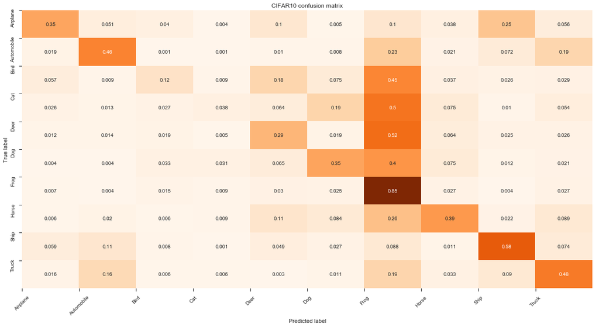

```python
# The CIFAR10 confusion matrix
cifar_conf = confusion_matrix(y_true=cifar_test_label, y_pred=cifar_predictions2)
cifar_conf_norm = cifar_conf / cifar_conf.sum(axis=1) # Normalisation

plt.figure(figsize=(20,10))
sns.heatmap(cifar_conf_norm, cbar=False, cmap=plt.cm.Oranges, annot=True)
plt.title("CIFAR10 confusion matrix")
plt.xlabel("Predicted label")
plt.ylabel("True label")
plt.xticks(range(10), cifar_labels, rotation=45)
plt.yticks(range(10), cifar_labels);
```

COMMENT  
The neural network improved the results for CIFAR10 data. The accurracy with only the neural network is $56 \%$ and with the use of Naive Bayes Classifier we got almost $40 \%$, we can get more with some changes on our neural network. Some labels are well-classified more than half of the times which is good.